# Lab 3: Gesture Recognition using Convolutional Neural Networks

In this lab you will train a convolutional neural network to make classifications on different hand gestures. By the end of the lab, you should be able to:

1. Load and split data for training, validation and testing
2. Train a Convolutional Neural Network
3. Apply transfer learning to improve your model

Note that for this lab we will not be providing you with any starter code. You should be able to take the code used in previous labs, tutorials and lectures and modify it accordingly to complete the tasks outlined below.

### What to submit

Submit a PDF file containing all your code, outputs, and write-up from parts 1-5. You can produce a PDF of your Google Colab file by going to **File > Print** and then save as PDF. The Colab instructions has more information. Make sure to review the PDF submission to ensure that your answers are easy to read. Make sure that your text is not cut off at the margins.

**Do not submit any other files produced by your code.**

Include a link to your colab file in your submission.

Please use Google Colab to complete this assignment. If you want to use Jupyter Notebook, please complete the assignment and upload your Jupyter Notebook file to Google Colab for submission.

## Colab Link

Include a link to your colab file here

Colab Link: https://drive.google.com/file/d/1mFppi1543bjrxDXNDGatem1Nht0hBauZ/view?usp=sharing

## Dataset

American Sign Language (ASL) is a complete, complex language that employs signs made by moving the hands combined with facial expressions and postures of the body. It is the primary language of many North Americans who are deaf and is one of several communication options used by people who are deaf or hard-of-hearing. The hand gestures representing English alphabet are shown below. This lab focuses on classifying a subset of these hand gesture images using convolutional neural networks. Specifically, given an image of a hand showing one of the letters A-I, we want to detect which letter is being represented.

[figure not shown]

## Part B. Building a CNN [50 pt]

For this lab, we are not going to give you any starter code. You will be writing a convolutional neural network from scratch. You are welcome to use any code from previous labs, lectures and tutorials. You should also write your own code.

You may use the PyTorch documentation freely. You might also find online tutorials helpful. However, all code that you submit must be your own.

Make sure that your code is vectorized, and does not contain obvious inefficiencies (for example, unecessary for loops, or unnecessary calls to unsqueeze()). Ensure enough comments are included in the code so that your TA can understand what you are doing. It is your responsibility to show that you understand what you write.

**This is much more challenging and time-consuming than the previous labs.** Make sure that you give yourself plenty of time by starting early.

### 1. Data Loading and Splitting [5 pt]

Download the anonymized data provided on Quercus. To allow you to get a heads start on this project we will provide you with sample data from previous years. Split the data into training, validation, and test sets.

Note: Data splitting is not as trivial in this lab. We want our test set to closely resemble the setting in which our model will be used. In particular, our test set should contain hands that are never seen in training!

Explain how you split the data, either by describing what you did, or by showing the code that you used. Justify your choice of splitting strategy. How many training, validation, and test images do you have?

For loading the data, you can use plt.imread as in Lab 1, or any other method that you choose. You may find torchvision.datasets.ImageFolder helpful. (see https://pytorch.org/docs/stable/torchvision/datasets.html?highlight=image%20folder#torchvision.datasets.ImageFolder )

```python
import numpy as np
import time
import torch
import torch.nn as nn
import torch.nn.functional as F
import torch.optim as optim
import torchvision
from torch.utils.data.sampler import SubsetRandomSampler
import torchvision.transforms as transforms

from torch.utils.data import random_split
```

```
1332 444 443
```

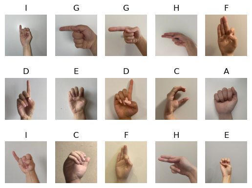

```python
classes = ('A', 'B', 'C', 'D', 'E', 'F', 'G', 'H', 'I')

transform = transforms.Compose([transforms.ToTensor(),
                                transforms.Normalize((0.5, 0.5, 0.5), (0.5, 0.5, 0.5))])

# 60% training, 20% validation and 20% testing samples split using "random_split"
images_dataset = torchvision.datasets.ImageFolder("./Lab3_Gestures_Summer/", transform=transform)
train_dataset, val_dataset, test_dataset = random_split(images_dataset, [0.6, 0.2, 0.2])

print(len(train_dataset), len(val_dataset), len(test_dataset))

# Prepare Dataloader
batch_size = 30
num_workers = 1

train_loader = torch.utils.data.DataLoader(train_dataset, batch_size=batch_size,
                                           num_workers=num_workers, shuffle=True)

val_loader = torch.utils.data.DataLoader(val_dataset, batch_size=batch_size,
                                           num_workers=num_workers, shuffle=True)

test_loader = torch.utils.data.DataLoader(test_dataset, batch_size=batch_size,
                                           num_workers=num_workers, shuffle=True)

import matplotlib.pyplot as plt

# looking at first image of each batch
k = 0
for images, labels in train_loader:
    image = images[0]
    # place the colour channel at the end, instead of at the beginning
    img = np.transpose(image, [1,2,0])
    # normalize pixel intensity values to [0, 1]
    img = img / 2 + 0.5
    plt.subplot(3, 5, k+1)
    plt.axis('off')
    plt.title(classes[labels[0]])
    plt.imshow(img)

    k += 1
    if k > 14:
        break
```

### 2. Model Building and Sanity Checking [15 pt]

### Part (a) Convolutional Network - 5 pt

Build a convolutional neural network model that takes the (224x224 RGB) image as input, and predicts the gesture letter. Your model should be a subclass of nn.Module. Explain your choice of neural network architecture: how many layers did you choose? What types of layers did you use? Were they fully-connected or convolutional? What about other decisions like pooling layers, activation functions, number of channels / hidden units?

```python
torch.manual_seed(10) # set the random seed
from math import floor

class CNNet(nn.Module):
    def __init__(self, name="CNNet"):
        super(CNNet, self).__init__()
        self.conv1 = nn.Conv2d(3, 5, 3)
        self.conv2 = nn.Conv2d(5, 10, 5)
        self.conv3 = nn.Conv2d(10, 25, 8)

        self.pool = nn.MaxPool2d(2, 2)

        # Computing the correct input size into the Fully Connected Layer
        self.a = floor((224 - 3 + 1)/2)
        self.b = floor((self.a - 5 + 1)/2)
        self.c = floor((self.b - 8 + 1)/2)

        self.fc1 = nn.Linear( 25*self.c*self.c , 32)
        self.fc2 = nn.Linear(32, 9)

        self.name = name

    def forward(self, img):
        x = self.pool(F.relu(self.conv1(img)))
        x = self.pool(F.relu(self.conv2(x)))
        x = self.pool(F.relu(self.conv3(x)))
        x = x.view(-1, 25*self.c*self.c)
        x = F.relu(self.fc1(x))
        x = self.fc2(x)
        return x
```

### Part (b) Training Code - 5 pt

Write code that trains your neural network given some training data. Your training code should make it easy to tweak the usual hyperparameters, like batch size, learning rate, and the model object itself. Make sure that you are checkpointing your models from time to time (the frequency is up to you). Explain your choice of loss function and optimizer.

```python
def get_model_name(name, batch_size, learning_rate, epoch):
    path = "model_{0}_bs{1}_lr{2}_epoch{3}".format(name,
                                                   batch_size,
                                                   learning_rate,
                                                   epoch)
    return path

def accuracy(net, data_loader):
    correct = 0
    total = 0
    for inputs, labels in data_loader:
        inputs = inputs.cuda()
        labels = labels.cuda()

        output = net(inputs)

        #select index with maximum prediction score
        pred = output.max(1, keepdim=True)[1]
        correct += pred.eq(labels.view_as(pred)).sum().item()
        total += inputs.shape[0]
    return correct / total

def train_net(net, batch_size=64, learning_rate=0.01, num_epochs=30):
    torch.manual_seed(1000)

    # Prepare Dataloader
    train_loader = torch.utils.data.DataLoader(train_dataset, batch_size=batch_size, shuffle=True)

    val_loader = torch.utils.data.DataLoader(val_dataset, batch_size=batch_size, shuffle=True)

    criterion = nn.CrossEntropyLoss()
    optimizer = optim.SGD(net.parameters(), lr=learning_rate, momentum=0.9)

    train_accuracy = np.zeros(num_epochs)
    val_accuracy = np.zeros(num_epochs)

    for epoch in range(num_epochs):  # loop over the dataset multiple times
        for i, data in enumerate(train_loader, 0):
            # Get the inputs
            inputs, labels = data
            inputs = inputs.cuda()
            labels = labels.cuda()
            # Zero the parameter gradients
            optimizer.zero_grad()
            # Forward pass, backward pass, and optimize
            outputs = net(inputs)
            loss = criterion(outputs, labels)
            loss.backward()
            optimizer.step()
            # Calculate the statistics

        train_accuracy[epoch] = accuracy(net, train_loader)
        val_accuracy[epoch] = accuracy(net, val_loader)
        print(("Epoch {}: Train accuracy: {} | Validation accuracy: {}")
              .format(
                    epoch + 1,
                    accuracy(net, train_loader),
                    accuracy(net, val_loader)))
        # Save the current model (checkpoint) to a file
        model_path = get_model_name(net.name, batch_size, learning_rate, epoch)
        torch.save(net.state_dict(), "./testing/"+model_path)
    print('Finished Training')

    return train_accuracy, val_accuracy, num_epochs
```

### Part (c) “Overfit” to a Small Dataset - 5 pt

One way to sanity check our neural network model and training code is to check whether the model is capable of “overfitting” or “memorizing” a small dataset. A properly constructed CNN with correct training code should be able to memorize the answers to a small number of images quickly.

Construct a small dataset (e.g. just the images that you have collected). Then show that your model and training code is capable of memorizing the labels of this small data set.

With a large batch size (e.g. the entire small dataset) and learning rate that is not too high, You should be able to obtain a 100% training accuracy on that small dataset relatively quickly (within 200 iterations).

```python
def overtrain_net(net, small_loader, learning_rate=0.01, num_epochs=30):
    torch.manual_seed(1000)

    criterion = nn.CrossEntropyLoss()
    optimizer = optim.SGD(net.parameters(), lr=learning_rate, momentum=0.9)

    for epoch in range(num_epochs):  # loop over the dataset multiple times
        for i, data in enumerate(small_loader, 0):
            # Get the inputs
            inputs, labels = data
            inputs = inputs.cuda()
            labels = labels.cuda()
            # Zero the parameter gradients
            optimizer.zero_grad()
            # Forward pass, backward pass, and optimize
            outputs = net(inputs)
            loss = criterion(outputs, labels)
            loss.backward()
            optimizer.step()
            # Calculate the statistics

        print(("Epoch {}: Train accuracy: {}")
              .format(epoch + 1, accuracy(net, small_loader)))
    print('Finished Training')
```

```python
classes = ('A', 'B', 'C', 'D', 'E', 'F', 'G', 'H', 'I')

transform = transforms.Compose([transforms.ToTensor(),
                                transforms.Normalize((0.5, 0.5, 0.5), (0.5, 0.5, 0.5))])

images_dataset = torchvision.datasets.ImageFolder("./Lab3_Gestures_Summer/", transform=transform)
small_dataset = random_split(images_dataset, [0.02, 0.98])

print(len(small_dataset[0]))

# Prepare Dataloader
batch_size = 45

small_loader = torch.utils.data.DataLoader(small_dataset[0], batch_size=batch_size, shuffle=True)

# Train the Model and try to overfit
CNN = CNNet()
CNN.cuda()

overtrain_net(CNN, small_loader, 0.01, num_epochs=120)
```

```
45
Epoch 1: Train accuracy: 0.08888888888888889
Epoch 2: Train accuracy: 0.08888888888888889
Epoch 3: Train accuracy: 0.08888888888888889
Epoch 4: Train accuracy: 0.08888888888888889
Epoch 5: Train accuracy: 0.08888888888888889
Epoch 6: Train accuracy: 0.08888888888888889
Epoch 7: Train accuracy: 0.1111111111111111
Epoch 8: Train accuracy: 0.17777777777777778
Epoch 9: Train accuracy: 0.24444444444444444
Epoch 10: Train accuracy: 0.2
Epoch 11: Train accuracy: 0.2
Epoch 12: Train accuracy: 0.15555555555555556
Epoch 13: Train accuracy: 0.2
Epoch 14: Train accuracy: 0.2222222222222222
Epoch 15: Train accuracy: 0.17777777777777778
Epoch 16: Train accuracy: 0.17777777777777778
Epoch 17: Train accuracy: 0.17777777777777778
Epoch 18: Train accuracy: 0.17777777777777778
Epoch 19: Train accuracy: 0.17777777777777778
Epoch 20: Train accuracy: 0.17777777777777778
Epoch 21: Train accuracy: 0.17777777777777778
Epoch 22: Train accuracy: 0.2
Epoch 23: Train accuracy: 0.2222222222222222
Epoch 24: Train accuracy: 0.26666666666666666
Epoch 25: Train accuracy: 0.3111111111111111
Epoch 26: Train accuracy: 0.35555555555555557
Epoch 27: Train accuracy: 0.3111111111111111
Epoch 28: Train accuracy: 0.28888888888888886
Epoch 29: Train accuracy: 0.28888888888888886
Epoch 30: Train accuracy: 0.3333333333333333
Epoch 31: Train accuracy: 0.37777777777777777
Epoch 32: Train accuracy: 0.37777777777777777
Epoch 33: Train accuracy: 0.4
Epoch 34: Train accuracy: 0.4222222222222222
Epoch 35: Train accuracy: 0.4666666666666667
Epoch 36: Train accuracy: 0.5777777777777777
Epoch 37: Train accuracy: 0.5777777777777777
Epoch 38: Train accuracy: 0.6888888888888889
Epoch 39: Train accuracy: 0.7111111111111111
```

[output cut: 67 more lines]

```
Epoch 107: Train accuracy: 1.0
Epoch 108: Train accuracy: 1.0
Epoch 109: Train accuracy: 1.0
Epoch 110: Train accuracy: 1.0
Epoch 111: Train accuracy: 1.0
Epoch 112: Train accuracy: 1.0
Epoch 113: Train accuracy: 1.0
Epoch 114: Train accuracy: 1.0
Epoch 115: Train accuracy: 1.0
Epoch 116: Train accuracy: 1.0
Epoch 117: Train accuracy: 1.0
Epoch 118: Train accuracy: 1.0
Epoch 119: Train accuracy: 1.0
Epoch 120: Train accuracy: 1.0
Finished Training
```

### 3. Hyperparameter Search [10 pt]

### Part (a) - 1 pt

List 3 hyperparameters that you think are most worth tuning. Choose at least one hyperparameter related to the model architecture.

```python
# batch size
# the kernel size in each convolutional layer
# num of epochs
```